# Model predictive control for autonomous lane following

### Define and plot curved lane

First, let us construct a curvy road for our autonomous car to operate in. Just run the cell below to generate the curvy road and visualize it.

```
Created centerline with 300 points
X range: [0.0, 150.0] m
Y range: [-2.0, 2.0] m
```

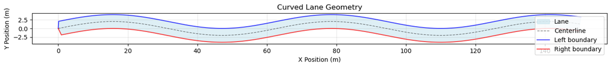

```python
# Define road parameters
# feel free to adjust these parameters to make the road wider or narrower, or make the curve more or less pronounced
LANE_WIDTH = 2.0  # Half-width of the lane (meters)
ROAD_LENGTH = 150.0  # Total length of the road (meters)
ANGULAR_FREQUENCY = 0.1  # Angular frequency of the sine wave
AMPLITUDE = 2.0  # Amplitude of the sine wave

# Create centerline: y = AMPLITUDE * sin(ANGULAR_FREQUENCY * x)
n_points_centerline = 300
s_values = np.linspace(0, ROAD_LENGTH, n_points_centerline)
centerline = create_curved_centerline(s_values, AMPLITUDE, ANGULAR_FREQUENCY)

print(f"Created centerline with {len(centerline)} points")
print(f"X range: [{centerline[:, 0].min():.1f}, {centerline[:, 0].max():.1f}] m")
print(f"Y range: [{centerline[:, 1].min():.1f}, {centerline[:, 1].max():.1f}] m")

# Compute lane boundaries
left_boundary, right_boundary = get_lane_boundaries(centerline, LANE_WIDTH)

# Plot the lane
fig, ax = plt.subplots(figsize=(14, 6))

plot_lane(ax, centerline, LANE_WIDTH, color="lightblue", alpha=0.4)
ax.plot(
    left_boundary[:, 0],
    left_boundary[:, 1],
    "b-",
    linewidth=1.5,
    alpha=0.7,
    label="Left boundary",
)
ax.plot(
    right_boundary[:, 0],
    right_boundary[:, 1],
    "r-",
    linewidth=1.5,
    alpha=0.7,
    label="Right boundary",
)

ax.set_xlabel("X Position (m)")
ax.set_ylabel("Y Position (m)")
ax.set_title("Curved Lane Geometry")
ax.legend()
ax.grid(True, alpha=0.3)
ax.set_aspect("equal")
plt.tight_layout()
plt.show()
```

### (a) Set up discrete time dynamics

Define the discrete time dynamics for the car using Euler integration with timestep size $\Delta t = 0.1$.

```python
def car_dynamics_dt(state: jnp.ndarray, control: jnp.ndarray, dt: float) -> jnp.ndarray:
    """
    Discrete time dynamics for the car using Euler integration.

    Args:
        state: (4,) array [px, vx, py, vy]
        control: (2,) array [ax, ay]
        params: Tuple containing any necessary parameters (e.g., mass)
        dt: Time step size
    Returns:
        next_state: (4,) array of next state
    """
    px, vx, py, vy = state
    ax, ay = control

    ###### add your code here
    next_state = jnp.array(
        [
            px + vx * dt,  # next px
            vx + ax * dt,  # next vx
            py + vy * dt,  # next py
            vy + ay * dt,  # next vy
        ]
    )
    ###### end of add your code here

    return next_state
```

Check that your dynamics function works by simulating the system with zero control input.

Take a look at the code to familiarize yourself with some of the helper functions.

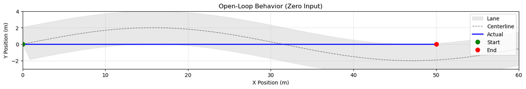

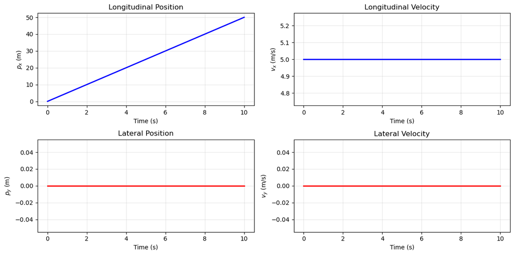

```python
# Run this cell after defining car_dynamics_dt above.

N_sim = 100  # number of time steps to simulate
dt = 0.1  # time step

# Start at origin, 5 m/s forward, centered
initial_state = jnp.array([0.0, 5.0, 0.0, 0.0])  # px, vx, py, vy

# Zero acceleration inputs for N_sim time steps
controls = jnp.array([[0.0, 0.0]] * N_sim)

# simulate open loop trajectory
trajectory_open_loop = simulate_open_loop(
    initial_state=initial_state,
    controls=controls,
    dynamics_func=car_dynamics_dt,
    dt=dt,
)

fig, ax = plot_scene(
    centerline,
    LANE_WIDTH,
    trajectory=trajectory_open_loop,
    title="Open-Loop Behavior (Zero Input)",
    xlim=(0, 60),
    ylim=(-3, 4),
)

plot_state_trajectories(trajectory_open_loop, N_sim, dt)
```

**Observe:** The car moves in a straight line (constant velocity, no steering). It doesn't follow the curved road. This is to be expected

### (b) Simple proportional controller

Now, let's try a simple proportional controller: $$a_y = k_p (p_y - {\text{center}}_y(p_x))$$

This tries to "pull" the car back toward the centerline at longitudinal position $p_x$.

Choose $K_p$ to be the gain corresponding to the infinite discrete-time LQR gain. That is, solve for $K_\infty$ for the system, and then select the gain corresponsing to the $a_y$ - $p_y$ entry.

Assume that $a_x=0$ (i.e., maintain velocity in the $x$ direction).

```python
# Simple proportional controller with given centerline and gain. Run this cell as is.
@jax.jit
def proportional_controller(
    state: jnp.ndarray, centerline: jnp.ndarray, kp: float = 2.0
) -> jnp.ndarray:
    """
    Simple proportional controller to keep car centered in lane.

    Args:
        state: (4,) array [px, vx, py, vy]
        centerline: (N, 2) array of centerline positions
        kp: Proportional gain for lateral control

    Returns:
        control: (2,) array [acceleration, steering_angle]
    """

    # Extract state variables
    px, vx, py, vy = state

    # Find desired lateral position (centerline) using interp
    py_center = jnp.interp(px, centerline[:, 0], centerline[:, 1])

    # Proportional control law
    ay = kp * (py - py_center)

    # No longitudinal control (maintain speed)
    ax = 0.0

    return jnp.array([ax, ay])
```

```python
# TODO: Compute the LQR gain $K_\infty$ for the discrete-time double integrator
##### add your code here
# define dt
dt = 0.1
# define matrices, A, B, Q, R\

A = np.array(
    [
        # px, vx, py, vy
        [1, dt, 0, 0],  # px
        [0, 1, 0, 0],  # vx
        [0, 0, 1, dt],  # py
        [0, 0, 0, 1],  # vy
    ]
)

B = np.array(
    [
        # ax, ay
        [0, 0],  # px
        [dt, 0],  # vx
        [0, 0],  # py
        [0, dt],  # vy
    ]
)

Q = np.array(
    [
        [10, 0, 0, 0],  # px
        [0, 1, 0, 0],  # vx
        [0, 0, 10, 0],  # py
        [0, 0, 0, 1],  # vy
    ]
)

R = np.array(
    [
        [1, 0],  # ax
        [0, 1],  # ay
    ]
)

# compute Pinf using scipy.linalg.solve_discrete_are
Pinf = scipy.linalg.solve_discrete_are(A, B, Q, R)
# compute Kinf using K = -(R + B.T @ Pinf @ B)^-1 @ (B.T @ Pinf @ A)
Kinf = -np.linalg.inv(R + B.T @ Pinf @ B) @ (B.T @ Pinf @ A)
print(Kinf)
###### end of add your code here
```

```
[[-2.76171489e+00 -2.64910235e+00 -3.32262538e-15 -1.17614366e-15]
 [ 3.01133591e-15 -5.42747529e-16 -2.76171489e+00 -2.64910235e+00]]
```

Let's evaluate the performance of your proportional controller.

Execute the cell below to simulate the closed-loop system using the proportional controller you just defined, and observe how the vehicle tracks the reference path.

[figure not shown]

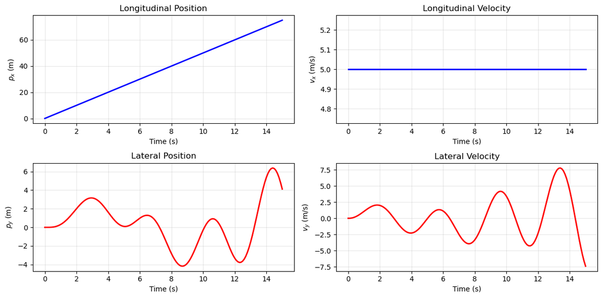

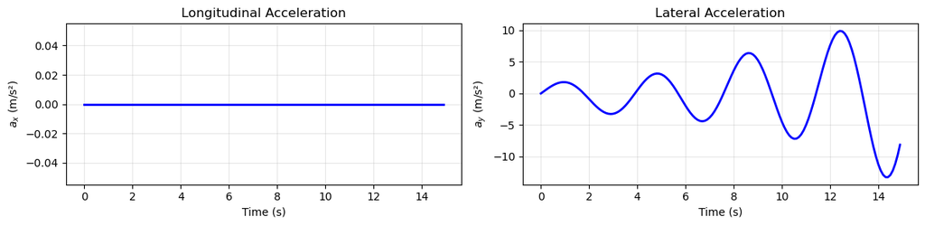

```python
# Run this cell after defining proportional_controller above.
N_sim = 150

# Start at origin, 5 m/s forward, centered
initial_state = jnp.array([0.0, 5.0, 0.0, 0.0])

# define policy
# setting kp to be the relevant value corresponding to (ay, py)
kp = Kinf[1, 2]  # Setting gain parameter to the LQR gain for lateral position
policy = functools.partial(proportional_controller, centerline=centerline, kp=kp)

# simulate closed loop trajectory
trajectory_proportional = simulate_closed_loop(
    initial_state=initial_state,
    policy=policy,
    n_steps=N_sim,
    dynamics_func=car_dynamics_dt,
    dt=dt,
)

controls_proportional = jax.vmap(policy)(trajectory_proportional[:-1])

fig, ax = plot_scene(
    centerline,
    LANE_WIDTH,
    trajectory=trajectory_proportional,
    title="Open-Loop Behavior (Zero Input)",
    xlim=(0, 60),
    ylim=(-3, 4),
)

plot_state_trajectories(trajectory_proportional, N_sim, dt)

plot_controls(controls_proportional, N_sim, dt)
```

**Observe:** The car still is not great at tracking the curvy road. You should observe significant ocsillations, resulting in the car going off the road.

### (c)(i) Simple look-ahead controller

We improve our proportional controller by introducing a notion of *look ahead* where instead of considering the current lateral error when computing the controller, we consider the projected lateral error at some look ahead distance $d_\mathrm{la}$ in front of the car.

This is similar to how humans drive. We look out the windshield to see what is ahead of use and that will determine our steering/acceleration in order to stay in our lane. We do not look straight down at our feet (suppose there is a glass bottom).

The projected look ahead lateral distance is

$$ p_y^\mathrm{proj} = p_y + d_\mathrm{la}\sin(\theta), \quad \theta = \arctan\frac{v_y}{v_x}$$$$p_x^\mathrm{proj} = p_x + d_\mathrm{la}\cos(\theta)$$$$ a_y = k_p(p_y^\mathrm{proj} - \text{center}_y(p_x^\mathrm{proj}))$$

Assume that $a_x=0$ (i.e., maintain velocitry in the $x$ direction).

Implement the look ahead controller and test it out. Try out various values for the gain and look ahead distance and choose values that you are content with. (It doesn't matter what you choose as long as it performs reasonably well. The point of this notebook is to show that MPC will perform much better than any carefully tuned proportional controller you can come up with).

```python
def lookahead_controller(
    state: jnp.ndarray, centerline: jnp.ndarray, kp: float = 2.0, lookahead: float = 3.0
) -> jnp.ndarray:
    """
    Simple proportional controller to keep car centered in lane.

    Args:
        state: (4,) array [px, vx, py, vy]
        centerline: (N, 2) array of centerline positions
        kp: Proportional gain for lateral control
        lookahead: Distance to look ahead

    Returns:
        control: (2,) array [acceleration, steering_angle]
    """
    # Extract state variables
    px, vx, py, vy = state

    # TODO: Implement the look ahead controller
    ###### add your code here
    theta = jnp.arctan2(vy, vx)
    # compute projected y position
    py_projected = py + lookahead * jnp.sin(theta)
    # compute projected x position
    px_projected = px + lookahead * jnp.cos(theta)
    # extract centerline at projected x position
    y_centerline_ahead = jnp.interp(px_projected, centerline[:, 0], centerline[:, 1])
    # compute y acceleration using proportional control law
    ay = kp * (py_projected - y_centerline_ahead)
    ax = 0
    ###### end of add your code here

    return jnp.array([ax, ay])
```

Construct your look-ahead controller

```python
# TODO: Construct your look-ahead controller
##### add your code here
kp = -5
lookahead = 4.0
###### end of add your code here
#


# define policy
policy_lookahead = functools.partial(
    lookahead_controller, centerline=centerline, kp=kp, lookahead=lookahead
)
```

Let's evaluate the performance of the look-ahead controller.

Execute the cell below to simulate the closed-loop system using the look-ahead controller you just defined, and observe how the vehicle tracks the reference path.

[figure not shown]

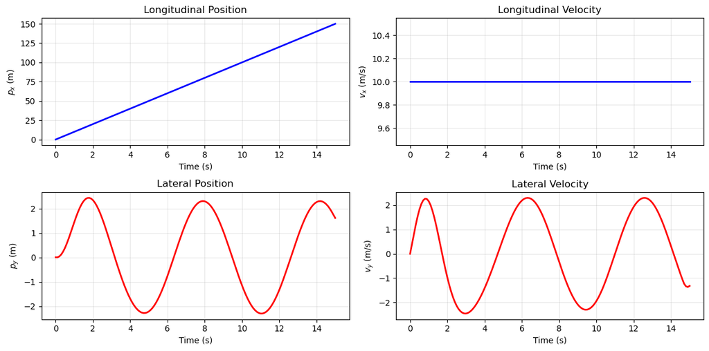

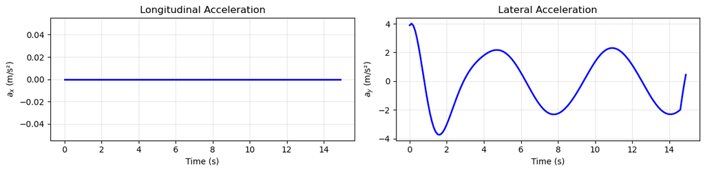

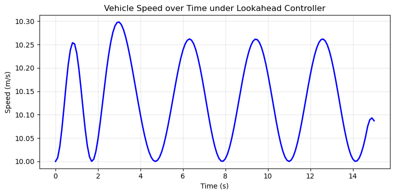

```python
# simulate the closed loop trajectory
N_sim = 150
dt = 0.1  # time step

# Start at origin, 5 m/s forward, centered
initial_state = jnp.array(
    [0.0, 10.0, 0.0, 0.0]
)  # feel free to test other initial states

# simulate closed loop trajectory
trajectory_lookahead = simulate_closed_loop(
    initial_state=initial_state,
    policy=policy_lookahead,
    n_steps=N_sim,
    dynamics_func=car_dynamics_dt,
    dt=dt,
)

controls_lookahead = jax.vmap(policy_lookahead)(trajectory_lookahead[:-1])

fig, ax = plot_scene(
    centerline,
    LANE_WIDTH,
    trajectory=trajectory_lookahead,
    title="Open-Loop Behavior (Zero Input)",
    xlim=(0, 60),
    ylim=(-3, 4),
)

plot_state_trajectories(trajectory_lookahead, N_sim, dt)

plot_controls(controls_lookahead, N_sim, dt)

velocity = jnp.sqrt(trajectory_lookahead[:, 1] ** 2 + trajectory_lookahead[:, 3] ** 2)
fig, ax = plt.subplots(figsize=(8, 4))
ax.plot(jnp.arange(N_sim + 1) * dt, velocity, "b-", linewidth=2)
ax.set_xlabel("Time (s)")
ax.set_ylabel("Speed (m/s)")
ax.set_title("Vehicle Speed over Time under Lookahead Controller")
ax.grid(True, alpha=0.3)
plt.tight_layout()
```

### (c)(ii) What if the car was moving faster?

Now, what if the car was moving faster longitudinally, what issues arise? We could adjust the look ahead distance based on the desired velocity. That is, instead of a look ahead distance, we consider look ahead time. Run the code below, try different desired velocity values, and get a sense of how the controller behaves with different parameter value choices.

```python
# improved lookahead controller with lookahead time instead of distance
@jax.jit
def lookahead_controller_improved(
    state: jnp.ndarray,
    centerline: jnp.ndarray,
    kp: float = 2.0,
    lookahead_time: float = 3.0,  # look ahead time in seconds
) -> jnp.ndarray:
    """
    Simple proportional controller to keep car centered in lane.

    Args:
        state: (4,) array [px, vx, py, vy]
        centerline: (N, 2) array of centerline positions
        kp: Proportional gain for lateral control
        lookahead_time: Time to look ahead in seconds

    Returns:
        control: (2,) array [acceleration, steering_angle]
    """
    # Extract state variables
    px, vx, py, vy = state
    speed = jnp.sqrt(vx**2 + vy**2)

    lookahead = lookahead_time * speed

    theta = jnp.arctan2(vy, vx)
    py_proj = py + lookahead * jnp.sin(theta)
    px_proj = px + lookahead * jnp.cos(theta)

    # Find desired lateral position (centerline) using interp
    py_center_proj = jnp.interp(px_proj, centerline[:, 0], centerline[:, 1])

    # Proportional control law
    ay = kp * (py_proj - py_center_proj)

    # No longitudinal control (maintain speed)
    ax = 0.0

    return jnp.array([ax, ay])
```

```python
# define initial x-speed. Try out different initial speeds
initial_xspeed = 15.0

# define lookahead (time) policy parameters
kp = -3.5  # feel free to change this value
lookahead_time = 0.8  # Try out different lookahead times

# define policy
policy_lookahead_improved = functools.partial(
    lookahead_controller_improved,
    centerline=centerline,
    kp=kp,
    lookahead_time=lookahead_time,
)
```

[figure not shown]

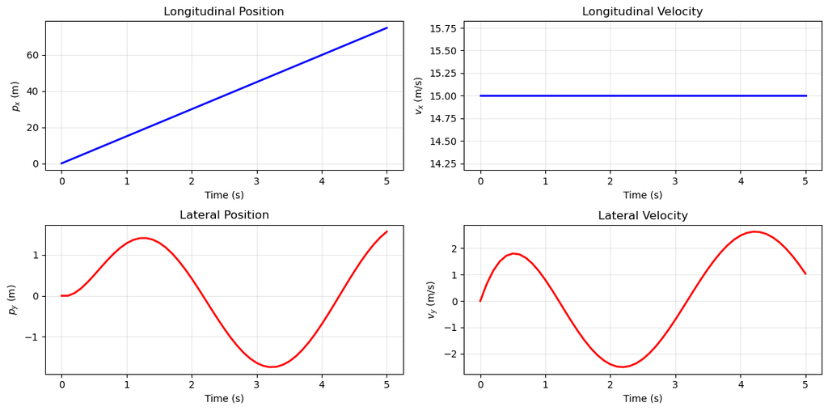

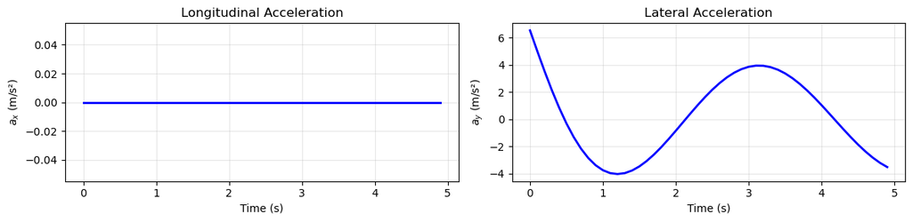

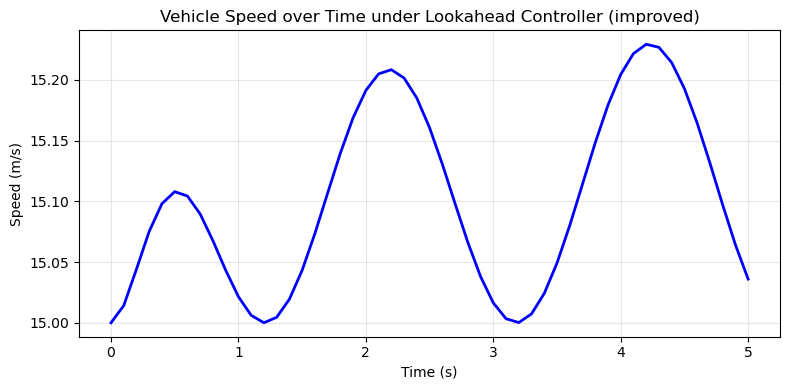

```python
# simulate the closed loop trajectory
N_sim = 50
dt = 0.1  # time step

# Start at origin, 5 m/s forward, centered
initial_state = jnp.array([0.0, initial_xspeed, 0.0, 0.0])


# simulate closed loop trajectory
trajectory_lookahead_improved = simulate_closed_loop(
    initial_state=initial_state,
    policy=policy_lookahead_improved,
    n_steps=N_sim,
    dynamics_func=car_dynamics_dt,
    dt=dt,
)

controls_lookahead_improved = jax.vmap(policy_lookahead_improved)(
    trajectory_lookahead_improved[:-1]
)


fig, ax = plot_scene(
    centerline,
    LANE_WIDTH,
    trajectory=trajectory_lookahead_improved,
    title="Open-Loop Behavior (Zero Input)",
    xlim=(0, 60),
    ylim=(-3, 4),
)

plot_state_trajectories(trajectory_lookahead_improved, N_sim, dt)
plot_controls(controls_lookahead_improved, N_sim, dt)

velocity = jnp.sqrt(
    trajectory_lookahead_improved[:, 1] ** 2 + trajectory_lookahead_improved[:, 3] ** 2
)
fig, ax = plt.subplots(figsize=(8, 4))
ax.plot(jnp.arange(N_sim + 1) * dt, velocity, "b-", linewidth=2)
ax.set_xlabel("Time (s)")
ax.set_ylabel("Speed (m/s)")
ax.set_title("Vehicle Speed over Time under Lookahead Controller (improved)")
ax.grid(True, alpha=0.3)
plt.tight_layout()
```

**Observe:** Yet, the controller isn't "perfect". You may find that you still require a lot of tuning, and that better parameter choices may still depend on the state variables. While the controller is simple enough to write down, finding good parameters can still be tricky.

### Let's try an MPC controller!

Previously, we just fixed the $v_x$ to be constant ($a_x=0$). But suppose that you wanted to instead have constant longitudinal velocity *along* the path, not just moving horizontally.

To start off, let's just consider an *unconstrained* MPC controller that aims to follow the centerline of the path with constant velocity. Then we will gradually build it up over to include constraints.

First, let us visualize the desired trajectory, which will be positions along the center line spaced so that it corresponds to the desired velocity.

Let us first set up some parameters

```python
# set up some MPC parameters that will used for the following problems
mpc_horizon_steps = 15  # Prediction horizon
desired_velocity = 6.0  # Desired forward velocity (m/s)
dt = 0.1  # time step size
initial_state = jnp.array(
    [0.0, desired_velocity - 2.0, 1.0, -2.0]
)  # starting velocity is not the same as desired velocity
N_sim = 100  # number of steps to simulate

n_state = 4
m_control = 2
```

Now, let's extract the center line of the curvy road, and visualize the road and our deisred trajectory to follow.

The figure on the right is a close up of the road. In particular, showing the desired trajectory over the `mpc_horizon_steps` length.

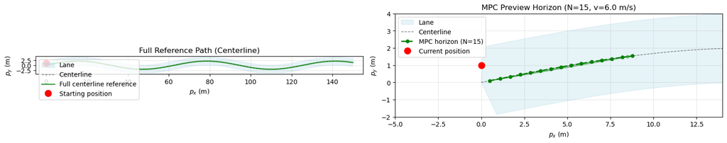

```python
# Given a current state, we find the closest point on the centerline and generate a reference trajectory
reference = get_centerline_reference(
    initial_state, centerline, mpc_horizon_steps, dt, desired_velocity
)


# Visualize reference trajectory
fig, axes = plt.subplots(1, 2, figsize=(16, 6))

# Left plot: Full road with centerline reference
plot_lane(axes[0], centerline, LANE_WIDTH, color="lightblue", alpha=0.3)
axes[0].plot(
    centerline[:, 0],
    centerline[:, 1],
    "g-",
    linewidth=2,
    alpha=0.7,
    label="Full centerline reference",
)
axes[0].plot(
    initial_state[0], initial_state[2], "ro", markersize=10, label="Starting position"
)
axes[0].set_xlabel("$p_x$ (m)")
axes[0].set_ylabel("$p_y$ (m)")
axes[0].set_title("Full Reference Path (Centerline)")
axes[0].legend()
axes[0].grid(True, alpha=0.3)
axes[0].set_aspect("equal")
axes[0].set_xlim(-5, ROAD_LENGTH + 5)

# Right plot: Zoomed view showing MPC horizon
plot_lane(axes[1], centerline, LANE_WIDTH, color="lightblue", alpha=0.3)
axes[1].plot(
    reference[:, 0],
    reference[:, 2],
    "g--",
    linewidth=2,
    marker="o",
    markersize=5,
    label=f"MPC horizon (N={mpc_horizon_steps})",
)
axes[1].plot(
    initial_state[0], initial_state[2], "ro", markersize=10, label="Current position"
)

# Add arrow showing prediction direction
axes[1].annotate(
    "",
    xy=(reference[-1, 0], reference[-1, 2]),
    xytext=(reference[0, 0], reference[0, 2]),
    arrowprops=dict(arrowstyle="->", color="green", lw=2, alpha=0.5),
)

axes[1].set_xlabel("$p_x$ (m)")
axes[1].set_ylabel("$p_y$ (m)")
axes[1].set_title(
    f"MPC Preview Horizon (N={mpc_horizon_steps}, v={desired_velocity} m/s)"
)
axes[1].legend()
axes[1].grid(True, alpha=0.3)
axes[1].set_aspect("equal")
axes[1].set_xlim(
    initial_state[0] - 5,
    initial_state[0] + mpc_horizon_steps * desired_velocity * dt + 5,
)
axes[1].set_ylim(initial_state[2] - 3, initial_state[2] + 3)

plt.tight_layout()
plt.show()
```

We wish to solve the following quadratic program at each time step:

$$ \min_{\mathbf{u}_0, \ldots, \mathbf{u}_{N-1}} \sum_{k=0}^{N-1} \left[ (\mathbf{x}_k - \mathbf{x}_{\text{ref},k})^\top Q (\mathbf{x}_k - \mathbf{x}_{\text{ref},k}) + \mathbf{u}_k^\top R \mathbf{u}_k \right] + (\mathbf{x}_N - \mathbf{x}_{\text{ref},N})^\top Q_f (\mathbf{x}_N - \mathbf{x}_{\text{ref},N}) $$

subject to: $$ \mathbf{x}_{k+1} = A \mathbf{x}_k + B \mathbf{u}_k, \quad k = 0, \ldots, N-1 $$ $$ \mathbf{x}_0 = \mathbf{x}_\mathrm{current} $$

Apply only the first control $\mathbf{u}_0$, then repeat (receding horizon).

```python
# Helper function to simplify plotting code. Run this cell as is.
def plot_results_combined(trajectory, controls, potholes=None):
    plot_scene(
        centerline,
        LANE_WIDTH,
        trajectory=trajectory,
        title=f"MPC Tracking (N={N_sim})",
        xlim=(0, 60),
        ylim=(-5, 5),
        potholes=potholes,
    )
    plot_state_trajectories(trajectory, N_sim, dt)
    plot_controls(controls, N_sim, dt)

    velocity = jnp.sqrt(
        trajectory[:, 1] ** 2 + trajectory[:, 3] ** 2
    )  # V = sqrt(vx^2 + vy^2)
    fig, ax = plt.subplots(figsize=(8, 4))
    ax.plot(jnp.arange(N_sim + 1) * dt, velocity, "b-", linewidth=2)
    ax.set_xlabel("Time (s)")
    ax.set_ylabel("Speed (m/s)")
    ax.set_title("Vehicle Speed over Time under MPC")
    ax.grid(True, alpha=0.3)
    plt.tight_layout()
```

### (d) Set up the MPC problem (no constraints)

Using `cvxpy`, set up the base MPC problem. Since we want solve the same problem but with a different reference and initial state as our system makes progress along the road, make sure to set those as `cvxpy.Parameters`.

Some parts are already filled in for you.

```python
# TODO: set up the MPC optimization problem using cvxpy.
# For values that need to be udpated each time (like initial state and reference trajectory), use cvxpy Parameters.

###### start of add your code here
# cost matrices
Q = cp.Constant(np.diag([10, 1, 10, 1]))  # state deviation cost matrix)
Qf = cp.Constant(np.diag([30, 5, 30, 5]))  # terminal state deviation cost matrix
R = cp.Constant(np.diag([1, 1]))  # control cost matrix

# dynamics matrices
A = cp.Constant(  # state transition matrix
    np.array([[1, dt, 0, 0], [0, 1, 0, 0], [0, 0, 1, dt], [0, 0, 0, 1]])
)
print(f"A:\n{A.value}")
B = cp.Constant(np.array([[0, 0], [dt, 0], [0, 0], [0, dt]]))

# optimization variables
states = cp.Variable((mpc_horizon_steps, n_state))
controls = cp.Variable((mpc_horizon_steps - 1, m_control))

# parameters that will be updated at each iteration
initial_state_param = cp.Parameter((n_state))
reference_states_params = cp.Parameter((mpc_horizon_steps, n_state))
states_deviation = states - reference_states_params

# objective function - quadratic cost on state deviation and control effort, with terminal cost on final state deviation
cost = cp.sum(
    [
        cp.quad_form(states_deviation[k], Q) for k in range(mpc_horizon_steps)
    ]  # state deviation cost
    + [
        cp.quad_form(controls[k], R) for k in range(mpc_horizon_steps - 1)
    ]  # control cost
    + [cp.quad_form(states_deviation[-1], Qf)]  # terminal state deviation cost
)

# constraints - initial condition and dynamics
constraint_dynamics = [
    states[k + 1] == A @ states[k] + B @ controls[k]
    for k in range(mpc_horizon_steps - 1)
]
initial_condition = states[0] == initial_state_param
constraints = [initial_condition, *constraint_dynamics]
###### end of add your code here


# Define the optimization problem
problem_base = cp.Problem(cp.Minimize(cost), constraints)
```

```
A:
[[1.  0.1 0.  0. ]
 [0.  1.  0.  0. ]
 [0.  0.  1.  0.1]
 [0.  0.  0.  1. ]]
```

```python
# Apply `functools.partial` on `get_centerline_reference` given some of the parameters already provided.
# This simplifies the function call in the MPC loop in later parts.
# Run this cell as is.
get_reference_from_state = functools.partial(
    get_centerline_reference,
    centerline=centerline,
    horizon=mpc_horizon_steps,
    dt=dt,
    desired_velocity=desired_velocity,
)
```

Now that you have defined the `cvxpy` problem, we can create a function that updates the problem given the current state, and solves it.

```python
# This function will be used in the MPC loop in later parts.
# Run this cell as is.
def mpc_solve_base(initial_state: jnp.ndarray, problem: cp.Problem) -> jnp.ndarray:
    """
    Solve the MPC problem given the current state and reference trajectory.

    Args:
        problem: CVXPY Problem instance
        initial_state: (n,) array of current state
        reference: (N, n) array of reference trajectory

    Returns:
        (m,) array for the optimal control input at the first time step
    """
    initial_state_param.value = np.array(initial_state)
    reference_states_params.value = np.array(get_reference_from_state(initial_state))

    problem.solve(solver=cp.OSQP)

    # Return the first optimal control input
    control_inputs = controls.value
    return jnp.array(control_inputs[0])


# simply the function call in the MPC loop in later parts.
policy_base = functools.partial(mpc_solve_base, problem=problem_base)
```

Now, let's simulate the system using our base MPC controller.

For some reasonable choice of cost matrices, you should see that MPC controller performs much better. The velocity should approach the desired velocity, and the car should track the centerline pretty well despite the initial state being offset from the centerline.

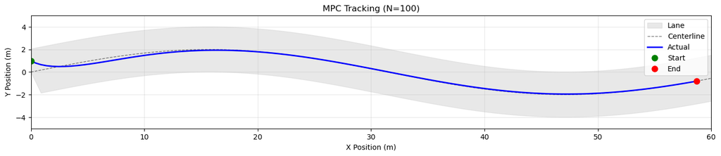

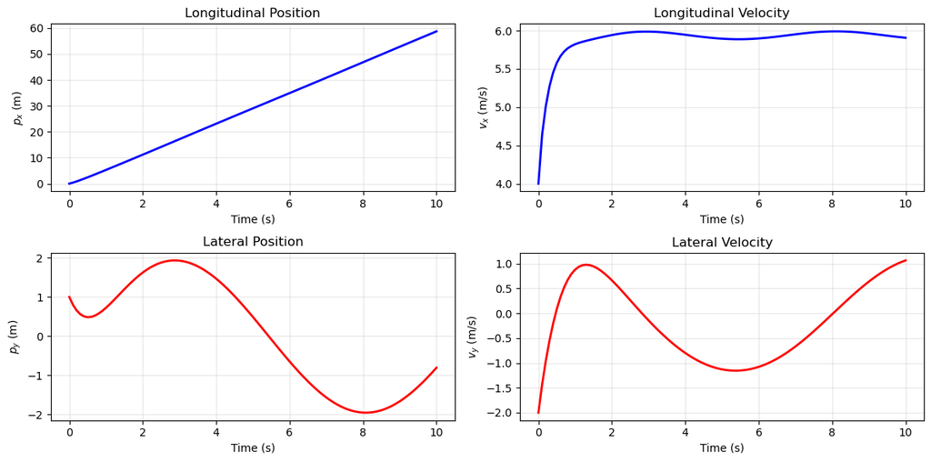

[figure not shown]

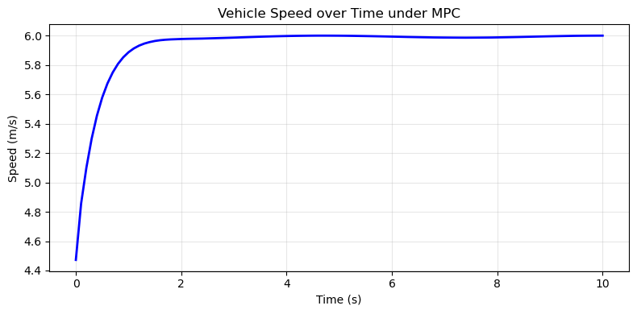

```python
trajectory_mpc_base = simulate_closed_loop(
    initial_state=initial_state,
    policy=policy_base,
    n_steps=N_sim,
    dynamics_func=car_dynamics_dt,
    dt=dt,
    has_numpy=True,
)

# recover controls
controls_mpc_base = jnp.array([policy(state) for state in trajectory_mpc_base[:-1]])

plot_results_combined(trajectory_mpc_base, controls_mpc_base)
```

### (e) Now, add input contraints.

Real vehicles have physical limits on acceleration. Add box constraints: $$-a_{\max} \leq a_x \leq a_{\max}$$ and $$-a_{\max} \leq a_y \leq a_{\max}$$

```python
a_max = 2.0  # max acceleration (m/s^2)
```

```python
# TODO: Construct a `cvxpy` problem like before, but with acceleration constraints.
# Copy the previous MPC setup and add acceleration constraints to the optimization problem.
# NOTE: your changes compared to the previous MPC setup should be minimal, and clearly commented.

###### start of add your code here
# cost matrices
Q = cp.Constant(np.diag([10, 1, 10, 1]))  # state deviation cost matrix)
Qf = cp.Constant(np.diag([30, 5, 30, 5]))  # terminal state deviation cost matrix
R = cp.Constant(np.diag([1, 1]))  # control cost matrix

# dynamics matrices
A = cp.Constant(  # state transition matrix
    np.array([[1, dt, 0, 0], [0, 1, 0, 0], [0, 0, 1, dt], [0, 0, 0, 1]])
)
B = cp.Constant(np.array([[0, 0], [dt, 0], [0, 0], [0, dt]]))

# optimization variables
states = cp.Variable((mpc_horizon_steps, n_state))
controls = cp.Variable((mpc_horizon_steps - 1, m_control))

# parameters that will be updated at each iteration
initial_state_param = cp.Parameter((n_state))
reference_states_params = cp.Parameter((mpc_horizon_steps, n_state))
states_deviation = states - reference_states_params

# objective function - quadratic cost on state deviation and control effort, with terminal cost on final state deviation
cost = cp.sum(
    [
        cp.quad_form(states_deviation[k], Q) for k in range(mpc_horizon_steps)
    ]  # state deviation cost
    + [
        cp.quad_form(controls[k], R) for k in range(mpc_horizon_steps - 1)
    ]  # control cost
    + [cp.quad_form(states_deviation[-1], Qf)]  # terminal state deviation cost
)

# constraints - initial condition, dynamics, AND ACCELRATION BOX CONSTRAINTS
constraint_dynamics = [
    states[k + 1] == A @ states[k] + B @ controls[k]
    for k in range(mpc_horizon_steps - 1)
]
initial_condition = states[0] == initial_state_param
control_bounds = [
    cp.abs(controls[k]) <= a_max for k in range(mpc_horizon_steps - 1)
]  # acelleration box constraint
constraints = [initial_condition, *constraint_dynamics, *control_bounds]
###### end of add your code here


# Define the optimization problem
problem_constrained = cp.Problem(cp.Minimize(cost), constraints)
```

```python
# this was previously defined, but we are redefining it here again anyways
get_reference_from_state = functools.partial(
    get_centerline_reference,
    centerline=centerline,
    horizon=mpc_horizon_steps,
    dt=dt,
    desired_velocity=desired_velocity,
)


# define the MPC policy. A similar function has been defined above, but we are redefining it here again anyways
def mpc_solve_constrained(
    initial_state: jnp.ndarray, problem: cp.Problem
) -> jnp.ndarray:
    """
    Solve the MPC problem given the current state and reference trajectory.

    Args:
        problem: CVXPY Problem instance
        initial_state: (n,) array of current state
        reference: (N, n) array of reference trajectory

    Returns:
        control_inputs: (N-1, m) array of optimal control inputs
    """
    initial_state_param.value = np.array(initial_state)
    reference_states_params.value = np.array(get_reference_from_state(initial_state))

    problem.solve(solver=cp.OSQP)

    # Extract the optimal control inputs from the problem
    control_inputs = controls.value
    return jnp.array(control_inputs[0])


# this policy is the MPC policy with acceleration constraints
policy_constrained = functools.partial(
    mpc_solve_constrained, problem=problem_constrained
)
```

Let's now simulate the system using our MPC controller with control constraints.

The resulting trajectory may appear similar to that from the unconstrained (base) policy. However, depending on your initial conditions and cost matrix choices, you may notice that the control inputs operate at or near their imposed limits.

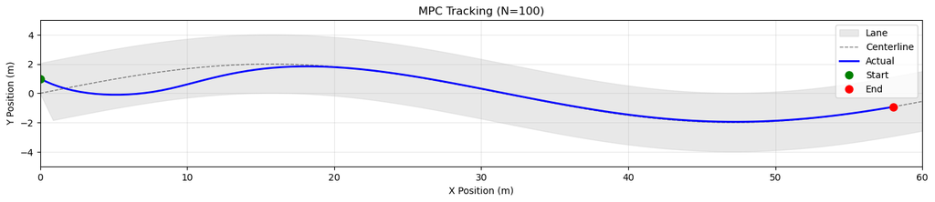

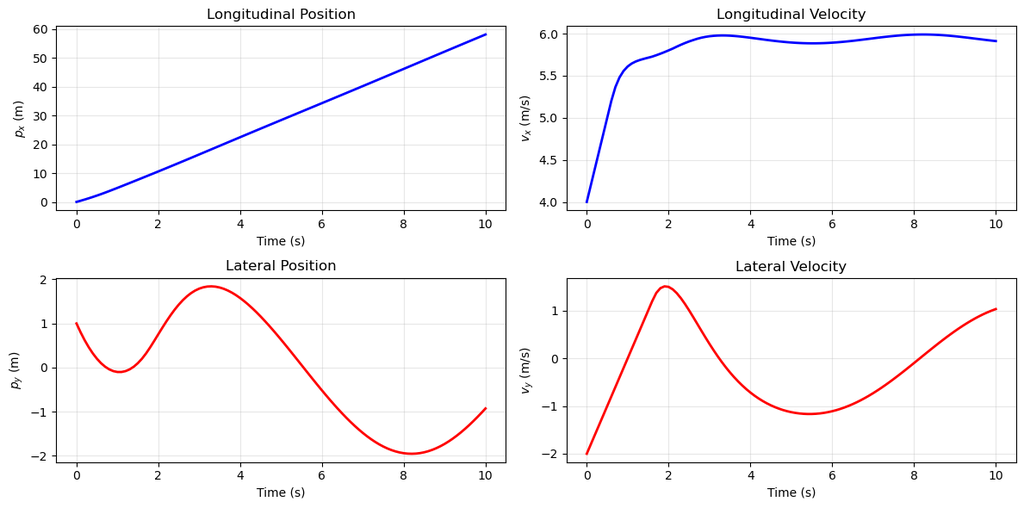

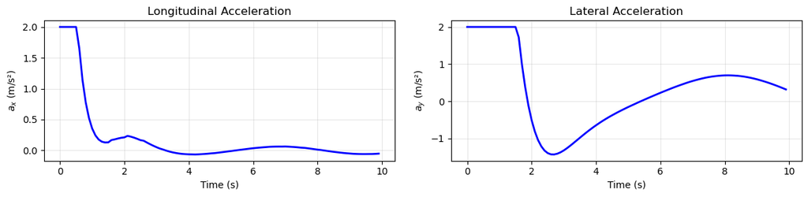

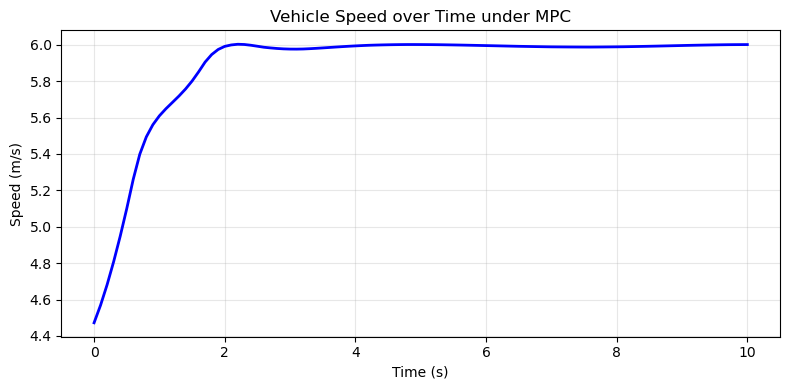

```python
trajectory_mpc_constrained = simulate_closed_loop(
    initial_state=initial_state,
    policy=policy_constrained,
    n_steps=N_sim,
    dynamics_func=car_dynamics_dt,
    dt=dt,
    has_numpy=True,
)

controls_mpc_constrained = jnp.array(
    [policy_constrained(state) for state in trajectory_mpc_constrained[:-1]]
)

plot_results_combined(trajectory_mpc_constrained, controls_mpc_constrained)
```

### (f) Now, let's consider road boundaries.

Adapt your MPC code from (e) to added road boundaries as a **soft constraint** by introducing a slack variable to these constraints. Generally, we would like to stay inside the lane, but if needed, we may deviate minimally from it.

If we let $\mathbf{p}_t$ be the $x,y$ position of the car at timestep $t$, and the upper and lower road boundaries corresponding to the desired lane position $\ell^\mathrm{upper}_t, \ell^\mathrm{lower}_t$, then we would like

$$ \mathbf{p}_t \leq \ell^\mathrm{upper}_t + \epsilon_\mathrm{upper}, \qquad \mathbf{p}_t \geq \ell^\mathrm{lower}_t - \epsilon_\mathrm{lower}, \quad \epsilon_\mathrm{upper} \geq 0, \quad \epsilon_\mathrm{lower} \geq 0 $$

Note: You could choose to use one slack variable, two for each upper/lower, or even one for each upper/lower and timesteps. The problem **should** still be convex.

Below is a function to extract the x-y coordinates of the road boundaries.

```python
# functions to get road boundaries. Run this cell as is.
# we use this function in later parts too.
@jax.jit
def get_road_boundaries(
    centerline: np.ndarray,
    half_road_width: float = LANE_WIDTH / 2,
) -> jnp.ndarray:
    """
    Generate entire road boundaries from centerline and half road width.

    Args:
        centerline: (N, 2) array of centerline positions
        half_road_width: Half-width of the road
    Returns:
        lower_boundary, upper_boundary: (N, 2) arrays of road boundaries
    """
    _tangents = jnp.diff(centerline, axis=0)
    tangents = jnp.concatenate([_tangents, _tangents[-1:, :]], axis=0)
    normals = jnp.stack([-tangents[:, 1], tangents[:, 0]], axis=1)
    normals /= jnp.linalg.norm(normals, axis=1, keepdims=True) + 1e-8
    return (
        centerline - normals * half_road_width,
        centerline + normals * half_road_width,
    )


centerline_lower, centerline_upper = get_road_boundaries(
    centerline=centerline, half_road_width=LANE_WIDTH / 2
)

# simplify function to get road boundaries over mpc horizon given current state
get_lower_boundary_from_state = functools.partial(
    get_centerline_reference,
    centerline=centerline_lower,
    horizon=mpc_horizon_steps,
    dt=dt,
    desired_velocity=desired_velocity,
)

get_upper_boundary_from_state = functools.partial(
    get_centerline_reference,
    centerline=centerline_upper,
    horizon=mpc_horizon_steps,
    dt=dt,
    desired_velocity=desired_velocity,
)

# example usage getting road boundaries over mpc horizon startingfrom initial state
lower_road_boundaries_xy = get_lower_boundary_from_state(initial_state)[:, [0, 2]]
upper_road_boundaries_xy = get_upper_boundary_from_state(initial_state)[:, [0, 2]]
```

```python
# TODO: Add road boundary constraints to your MPC setup with control constraints.
# Copy the previous MPC setup (with acceleration constraints) and add road boundary constraints to the optimization problem.
# NOTE: your changes compared to the previous MPC setup should be minimal, and clearly commented.

###### start of add your code here
# cost matrices
Q = cp.Constant(np.diag([10, 1, 10, 1]))  # state deviation cost matrix)
Qf = cp.Constant(np.diag([30, 5, 30, 5]))  # terminal state deviation cost matrix
R = cp.Constant(np.diag([0.1, 0.1]))  # control cost matrix
boundary_slack_cost = cp.Constant(1000)  # cost for violating lane boundary constraints

# dynamics matrices
A = cp.Constant(  # state transition matrix
    np.array([[1, dt, 0, 0], [0, 1, 0, 0], [0, 0, 1, dt], [0, 0, 0, 1]])
)
B = cp.Constant(np.array([[0, 0], [dt, 0], [0, 0], [0, dt]]))


# optimization variables
states = cp.Variable((mpc_horizon_steps, n_state))
controls = cp.Variable((mpc_horizon_steps - 1, m_control))
boundary_slack = cp.Variable()

# parameters that will be updated at each iteration
initial_state_param = cp.Parameter((n_state))
reference_states_params = cp.Parameter((mpc_horizon_steps, n_state))
states_deviation = states - reference_states_params
road_lower_bounds_params = cp.Parameter((mpc_horizon_steps, 2))
road_upper_bounds_params = cp.Parameter((mpc_horizon_steps, 2))

# objective function - quadratic cost on state deviation and control effort, with terminal cost on final state deviation
cost = cp.sum(
    [
        cp.quad_form(states_deviation[k], Q) for k in range(mpc_horizon_steps)
    ]  # state deviation cost
    + [
        cp.quad_form(controls[k], R) for k in range(mpc_horizon_steps - 1)
    ]  # control cost
    + [cp.quad_form(states_deviation[-1], Qf)]  # terminal state deviation cost
    + [boundary_slack_cost * boundary_slack**2]
)

# constraints - initial condition, dynamics, control bounds, and lane boundary constraints
constraint_dynamics = [
    states[k + 1] == A @ states[k] + B @ controls[k]
    for k in range(mpc_horizon_steps - 1)
]
initial_condition = states[0] == initial_state_param
control_bounds = [cp.abs(controls[k]) <= a_max for k in range(mpc_horizon_steps - 1)]


# lower_road_boundaries_x = lower_road_boundaries_xy[0, :]
# lower_road_boundaries_y =lower_road_boundaries_xy[:, 1]
# lower_road_boundary_values = jnp.interp(states[:, 0], lower_road_boundaries_x, lower_road_boundaries_y)

# add box constraints with slack on px and py
lane_bounds_constraint = [
    *[
        states[k, 2] >= road_lower_bounds_params[k, 1] - boundary_slack
        for k in range(mpc_horizon_steps)
    ],
    *[
        states[k, 2] <= road_upper_bounds_params[k, 1] + boundary_slack
        for k in range(mpc_horizon_steps)
    ],
    boundary_slack >= 0,
]

constraints = [
    initial_condition,
    *constraint_dynamics,
    *control_bounds,
    *lane_bounds_constraint,
]
###### end of add your code here


# Solve the optimization problem
problem_constrained_road = cp.Problem(cp.Minimize(cost), constraints)
```

```python
# this was previously defined, but we are redefining it here again anyways
get_reference_from_state = functools.partial(
    get_centerline_reference,
    centerline=centerline,
    horizon=mpc_horizon_steps,
    dt=dt,
    desired_velocity=desired_velocity,
)


# define the MPC solve function where cvxpy parameters are updated each time. Run this cell as is.
def mpc_solve_constrained_road(
    initial_state: jnp.ndarray, problem: cp.Problem
) -> jnp.ndarray:
    """
    Solve the MPC problem given the current state and reference trajectory.

    Args:
        problem: CVXPY Problem instance
        initial_state: (n,) array of current state
        reference: (N, n) array of reference trajectory

    Returns:
        control_inputs: (N-1, m) array of optimal control inputs
    """
    initial_state_param.value = np.array(initial_state)
    reference_states_params.value = np.array(get_reference_from_state(initial_state))
    road_lower_bounds_params.value = np.array(
        get_lower_boundary_from_state(initial_state)[:, [0, 2]]
    )
    road_upper_bounds_params.value = np.array(
        get_upper_boundary_from_state(initial_state)[:, [0, 2]]
    )

    problem.solve(solver=cp.OSQP)

    # # debug
    # print(f"Problem Status: {problem.status}")

    # Extract the optimal control inputs from the problem
    control_inputs = controls.value
    return jnp.array(control_inputs[0])


# this policy is the MPC policy with road constraints
policy_constrained_road = functools.partial(
    mpc_solve_constrained_road, problem=problem_constrained_road
)
```

Let's now simulate the system using our MPC controller with control constraints and road boundary (soft) constraints

Try with an initial state where the car is initially moving off the road and see how this MPC policy steers it back to the road.

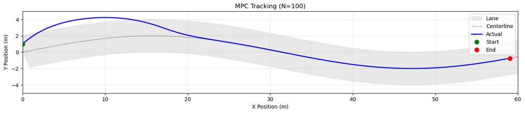

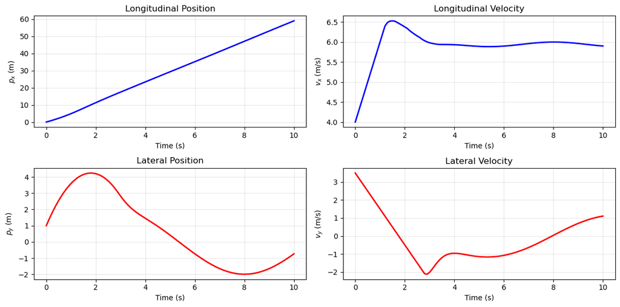

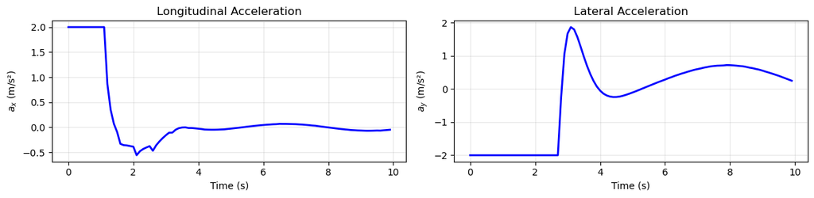

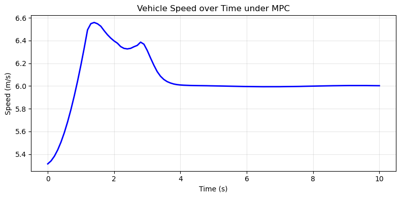

```python
initial_state = jnp.array([0.0, 4.0, 1.0, 3.5])
trajectory_mpc_constrained_road = simulate_closed_loop(
    initial_state=initial_state,
    policy=policy_constrained_road,
    n_steps=N_sim,
    dynamics_func=car_dynamics_dt,
    dt=dt,
    has_numpy=True,
)

controls_mpc_constrained_road = jnp.array(
    [policy_constrained_road(state) for state in trajectory_mpc_constrained_road[:-1]]
)

plot_results_combined(trajectory_mpc_constrained_road, controls_mpc_constrained_road)
```

As you drive on the road, nasty (circular) potholes appear and you need to avoid them! Add **obstacle avoidance** constaints to your MPC problem.

Note that the potholes are non-convex (specifically, not linear) constraints and therefore you need to linearize then.

Some helper code is provided. You need to add the obstacle constraints to your MPC problem from the previous part. That is, your MPC problem should also include acceleration and road boundary constraints.

We set up a pothole constraint $g(\mathbf{p}) \leq 0$ where $\mathbf{p}$ is the position. Then we need to linearize the constraint at each point along the MPC horizon, resulting in $$G_t\mathbf{p}_t + h_t \leq 0.$$ This needs to be applied for each point along the MPC horizon and for each pothole.

To ensure the problem remains feasible, use slack variables to relax this constraint.

```python
# Helper functions to set up pothole constraint function, linearization, and example usage.
# Run this cell as is.
@jax.jit
def pothole_constraint(position, pothole_center, pothole_radius):
    """
    Check if the position is outside the pothole with a safety margin.
     g(x) <= 0 indicates car is outside pothole.

    Args:
        position: (2,) array of current position [px, py]
        pothole_center: (2,) array of pothole center [px, py]
        pothole_radius: Radius of the pothole
    Returns:
        constraint: Boolean indicating if outside the pothole
    """
    distance = jnp.linalg.norm(position - pothole_center)
    return pothole_radius**2 - distance**2


@jax.jit
def linearize_pothole_constraint(position, pothole_center, pothole_radius):
    """
    Linearize the pothole constraint around the current position.

    Args:
        position: (2,) array of current position [px, py]
        pothole_center: (2,) array of pothole center [px, py]
        pothole_radius: Radius of the pothole
    Returns:
        linear: linear term in the affine approximation
        constant: constant term in the affine approximation
    """
    linear = jax.grad(pothole_constraint, argnums=0)(
        position, pothole_center, pothole_radius
    )
    constant = pothole_constraint(position, pothole_center, pothole_radius) - jnp.dot(
        linear, position
    )
    return linear, constant


# example usage of linearized pothole constraint
position = jnp.array([1.0, 0.5])
pothole_center = jnp.array([0.0, 0.0])
pothole_radius = 0.5
linear, constant = linearize_pothole_constraint(
    position, pothole_center, pothole_radius
)
pothole_constraint_linear = linear @ position + constant >= 0 # I think this is how u would use it
print(pothole_constraint_linear)
```

```
False
```

Let us define a number of potholes.

Below is some code to define the potholes and some additional helper code to linearize the pothole constraints for multiple potholes

```python
# defining multiple potholes. Example usage of linearizing all pothole constraints below. Run this cell as is.
pothole_centers = jnp.array([[20.0, 2.0], [30.0, 0.0], [40.0, -2.0]])
pothole_radii = jnp.array([0.75, 0.75, 0.75])


# simplifying function to linearize all pothole constraints at once)
def _linearize_pothole_constraint_vmap(position, pothole_centers, pothole_radii):
    return jax.vmap(linearize_pothole_constraint, in_axes=(None, 0, 0))(
        position, pothole_centers, pothole_radii
    )


linearize_pothole_constraint_vmap = functools.partial(
    _linearize_pothole_constraint_vmap,
    pothole_centers=pothole_centers,
    pothole_radii=pothole_radii,
)

# example usage of linearizing all pothole constraints for multiple positions
position = jnp.ones([15, 2])
test_pothole_linearization = jax.vmap(linearize_pothole_constraint_vmap, in_axes=(0))(
    position
)
```

```python
# TODO: Add pothole constraints to your MPC setup with control constraints and road boundary constraints.
# Copy the previous MPC setup (with acceleration constraints and road boundary constraints) and add pothole constraints to the optimization problem.
# NOTE: your changes compared to the previous MPC setup should be minimal, and clearly commented.

###### start of add your code here
# cost matrices
Q = cp.Constant(np.diag([10, 1, 10, 1]))  # state deviation cost matrix)
Qf = cp.Constant(np.diag([30, 5, 30, 5]))  # terminal state deviation cost matrix
R = cp.Constant(np.diag([1, 1]))  # control cost matrix
boundary_slack_cost = cp.Constant(100)
pothole_slack_cost = cp.Constant(100000)

# dynamics matrices
A = cp.Constant(  # state transition matrix
    np.array([[1, dt, 0, 0], [0, 1, 0, 0], [0, 0, 1, dt], [0, 0, 0, 1]])
)
B = cp.Constant(np.array([[0, 0], [dt, 0], [0, 0], [0, dt]]))


# optimization variables
states = cp.Variable((mpc_horizon_steps, n_state))
controls = cp.Variable((mpc_horizon_steps - 1, m_control))
boundary_slack = cp.Variable()
pothole_slack = cp.Variable()

# parameters that will be updated at each iteration
initial_state_param = cp.Parameter((n_state))
reference_states_params = cp.Parameter((mpc_horizon_steps, n_state))
states_deviation = states - reference_states_params
road_lower_bounds_params = cp.Parameter((mpc_horizon_steps, 2))
road_upper_bounds_params = cp.Parameter((mpc_horizon_steps, 2))

n_potholes = pothole_centers.shape[0]
pothole_constraint_linear_params = cp.Parameter((mpc_horizon_steps, n_potholes, 2))
pothole_constraint_constant_params = cp.Parameter((mpc_horizon_steps, n_potholes))

# objective function - quadratic cost on state deviation and control effort, with terminal cost on final state deviation
cost = cp.sum(
    [
        cp.quad_form(states_deviation[k], Q) for k in range(mpc_horizon_steps)
    ]  # state deviation cost
    + [
        cp.quad_form(controls[k], R) for k in range(mpc_horizon_steps - 1)
    ]  # control cost
    + [cp.quad_form(states_deviation[-1], Qf)]  # terminal state deviation cost
    + [boundary_slack_cost * boundary_slack**2]
    + [pothole_slack_cost * pothole_slack**2]
)

# constraints - initial condition, dynamics, control bounds, and lane boundary constraints
constraint_dynamics = [
    states[k + 1] == A @ states[k] + B @ controls[k]
    for k in range(mpc_horizon_steps - 1)
]
initial_condition = states[0] == initial_state_param
control_bounds = [cp.abs(controls[k]) <= a_max for k in range(mpc_horizon_steps - 1)]

# add box constraints with slack on px and py
lane_bounds_constraint = [
    *[
        states[k, 2] >= road_lower_bounds_params[k, 1] - boundary_slack
        for k in range(mpc_horizon_steps)
    ],
    *[
        states[k, 2] <= road_upper_bounds_params[k, 1] + boundary_slack
        for k in range(mpc_horizon_steps)
    ],
    boundary_slack >= 0,
]

pothole_constraints = [
    *[
        pothole_constraint_linear_params[k, i] @ states[k, [0, 2]] \
            + pothole_constraint_constant_params[k, i] <= pothole_slack \
        for i in range(n_potholes) for k in range(mpc_horizon_steps)
    ],
    pothole_slack >= 0,
]

# combine all constraints to one list
constraints = [
    initial_condition,
    *constraint_dynamics,
    *control_bounds,
    *lane_bounds_constraint,
    *pothole_constraints,
]
###### end of add your code here


# Solve the optimization problem
problem_constrained_road_pothole = cp.Problem(cp.Minimize(cost), constraints)
```

```python
def mpc_solve_constrained_road_pothole(
    initial_state: jnp.ndarray, problem: cp.Problem
) -> jnp.ndarray:
    """
    Solve the MPC problem given the current state and reference trajectory.

    Args:
        problem: CVXPY Problem instance
        initial_state: (n,) array of current state
        reference: (N, n) array of reference trajectory

    Returns:
        control_inputs: (N-1, m) array of optimal control inputs
    """
    reference_states = get_reference_from_state(initial_state)
    initial_state_param.value = np.array(initial_state)
    reference_states_params.value = np.array(reference_states)
    road_lower_bounds_params.value = np.array(
        get_lower_boundary_from_state(initial_state)[:, [0, 2]]
    )
    road_upper_bounds_params.value = np.array(
        get_upper_boundary_from_state(initial_state)[:, [0, 2]]
    )

    reference_positions = np.array(reference_states)[:, [0, 2]]
    linear, constant = jax.vmap(linearize_pothole_constraint_vmap, in_axes=(0))(
        reference_positions
    )

    pothole_constraint_linear_params.value = np.array(linear)
    pothole_constraint_constant_params.value = np.array(constant)

    problem.solve(solver=cp.OSQP)

    # Extract the optimal control inputs from the problem
    control_inputs = controls.value
    return jnp.array(control_inputs[0])


policy_constrained_road_pothole = functools.partial(
    mpc_solve_constrained_road_pothole, problem=problem_constrained_road_pothole
)
```

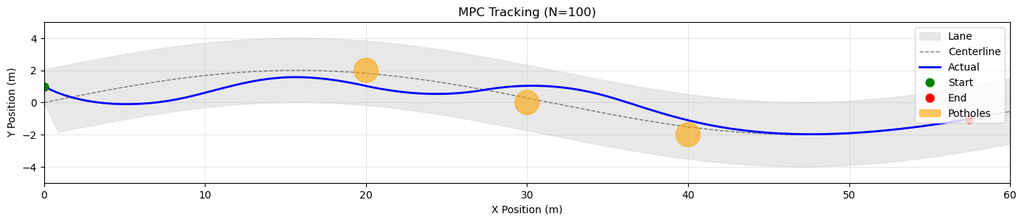

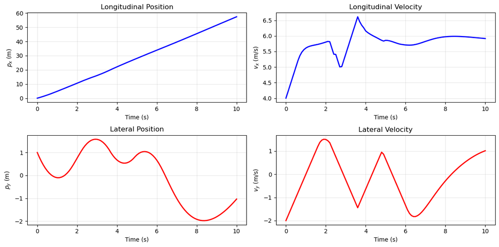

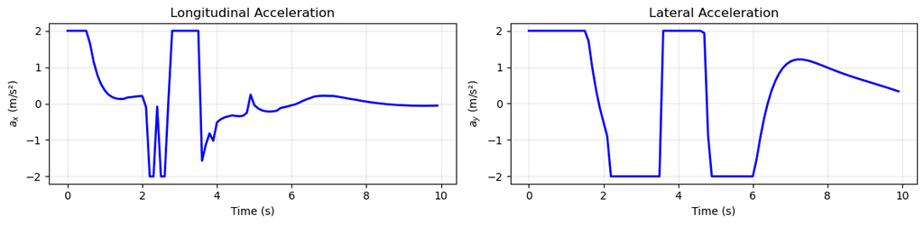

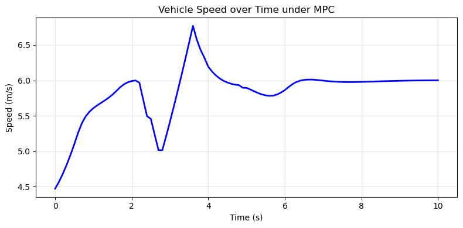

```python
initial_state = jnp.array(
    [0.0, desired_velocity - 2.0, 1.0, -2.0]
)  # starting velocity is not the same as desired velocity
trajectory_mpc_constrained_road_pothole = simulate_closed_loop(
    initial_state=initial_state,
    policy=policy_constrained_road_pothole,
    n_steps=N_sim,
    dynamics_func=car_dynamics_dt,
    dt=dt,
    has_numpy=True,
)

controls_mpc_constrained_road_pothole = jnp.array(
    [
        policy_constrained_road_pothole(state)
        for state in trajectory_mpc_constrained_road_pothole[:-1]
    ]
)

plot_results_combined(
    trajectory_mpc_constrained_road_pothole,
    controls_mpc_constrained_road_pothole,
    potholes=(pothole_centers, pothole_radii),
)
```

Congratulations! You have just created a MPC controller! Notice that the control sequence resulting from your MPC controller looks more "spiky" than the simple proportional controllers. And the MPC controller is able to respect the control constraints.

There's plenty of ways to add more complexity to this controller/problem. Such as adding noise to the system as you simulate it, or only including the pothole constraints when they come into view.